# Gut GVHD Pilot

#### Data Loading

Sample SLV14 was chosen because it is an example of severe GVHD. 16 micrometer resolution was chosen due to limitations of computational resources.

```r
library(Seurat)
library(dplyr)

matrix_dir <- "Data/SLV14/filtered_feature_bc_matrix"
spatial_dir <- "Data/SLV14/spatial"

counts <- Read10X(data.dir = matrix_dir)
slv14 <- CreateSeuratObject(counts, assay = "Spatial", project = "SLV14")
slv14 <- subset(slv14, subset = nCount_Spatial >= 50)

img <- Read10X_Image(image.dir = spatial_dir, image.name = "tissue_lowres_image.png")
img <- img[Cells(slv14)]
DefaultAssay(img) <- "Spatial"
slv14[["slice1"]] <- img  # attach image to the object

slv14
```

```
An object of class Seurat
18085 features across 30294 samples within 1 assay
Active assay: Spatial (18085 features, 0 variable features)
 1 layer present: counts
 1 spatial field of view present: slice1
```

#### Data Quality Control

I used Median Absolute Deviations as my standard for filtering spots. Data poitns above/below 3 MADs for any of the criterion (features, counts, percent.mt) were excluded from the dataset.

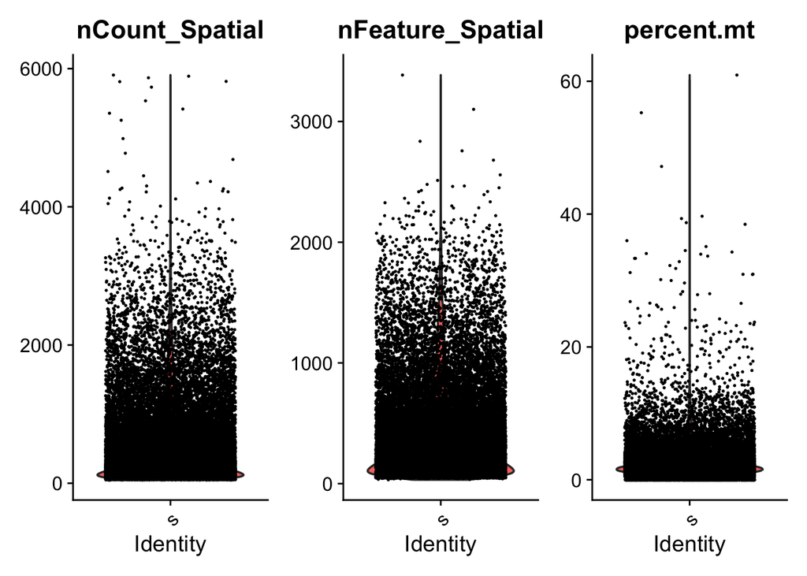

```r
slv14[["percent.mt"]] <- PercentageFeatureSet(slv14, pattern = "^MT-")

VlnPlot(slv14, features = c("nCount_Spatial", "nFeature_Spatial", "percent.mt"))
```

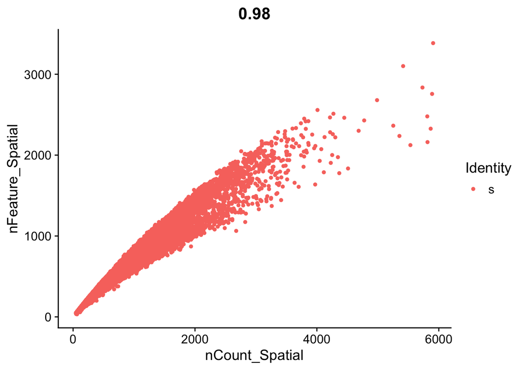

```r
FeatureScatter(slv14, feature1 = "nCount_Spatial", feature2 = "nFeature_Spatial")
```

```r
log_count <- log1p(slv14$nCount_Spatial)
med_count <- median(log_count)
mad_val_count <- mad(log_count)

count_lower_log <- (med_count - (mad_val_count*3))
count_upper_log <- (med_count + (mad_val_count*3))

count_lower <- expm1(count_lower_log)
count_upper <- expm1(count_upper_log)

log_feature <- log1p(slv14$nFeature_Spatial)
med_feature <- median(log_feature)
mad_val_feature <- mad(log_feature)

feature_lower_log <- (med_feature - (mad_val_feature*3))
feature_upper_log <- (med_feature + (mad_val_feature*3))

feature_lower <- expm1(feature_lower_log)
feature_upper <- expm1(feature_upper_log)

mt_upper = median(slv14$percent.mt) + (3 * mad(slv14$percent.mt))

dim(slv14)
```

```
[1] 18085 30294
```

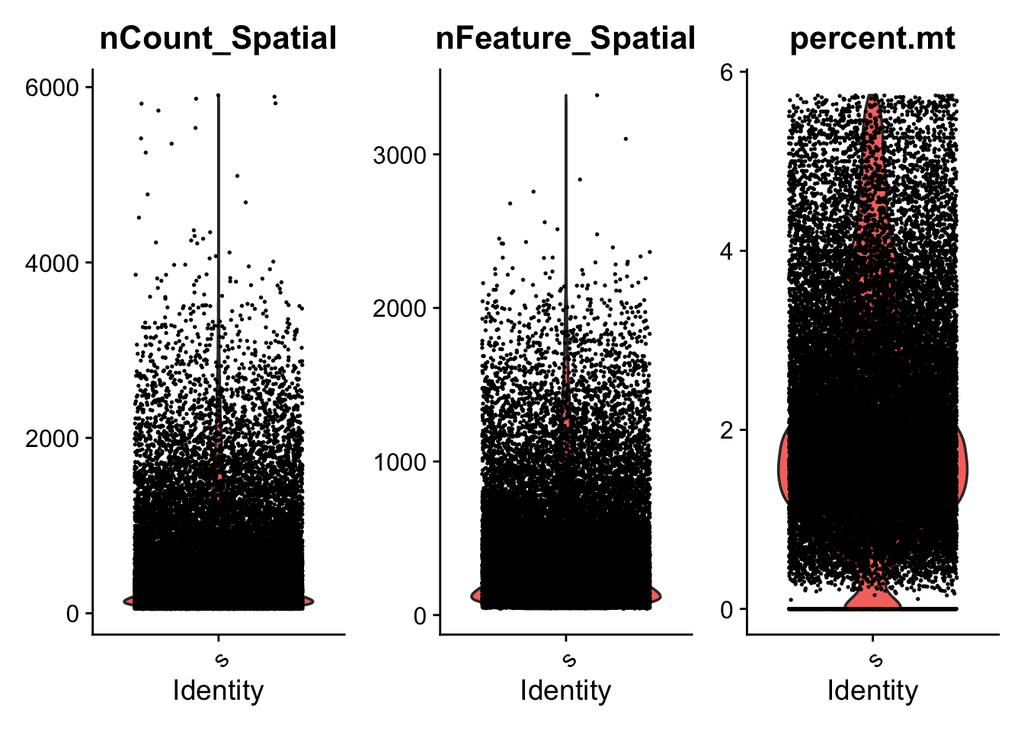

```r
slv14 <- subset(slv14, subset = nCount_Spatial < count_upper & nCount_Spatial > count_lower & nFeature_Spatial > feature_lower & nFeature_Spatial < feature_upper & percent.mt < mt_upper)

VlnPlot(slv14, features = c("nCount_Spatial", "nFeature_Spatial", "percent.mt"))
```

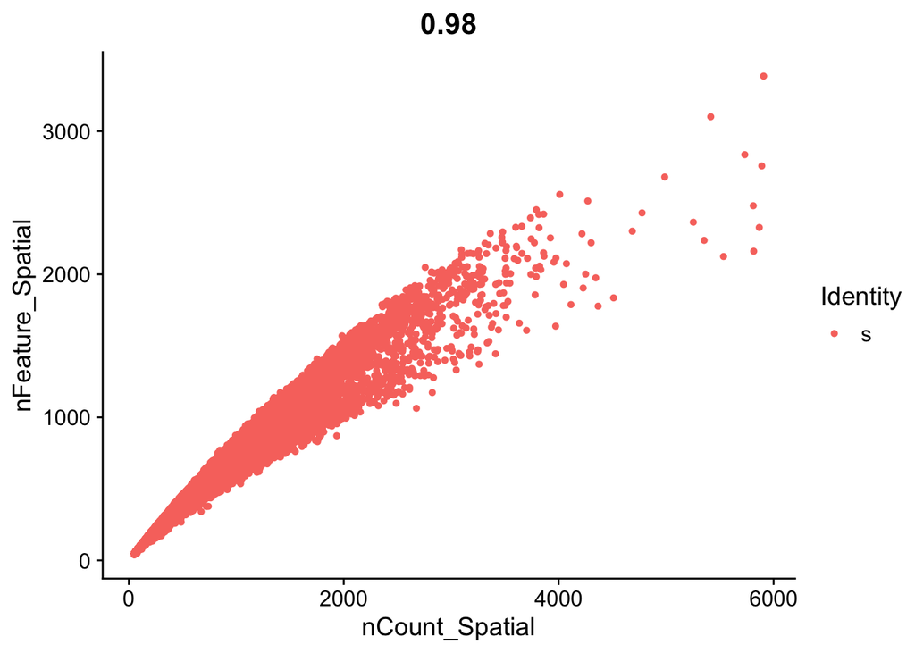

```r
FeatureScatter(slv14, feature1 = "nCount_Spatial", feature2 = "nFeature_Spatial")
```

```r
dim(slv14)
```

```
[1] 18085 28038
```

#### Data Normalization and Scaling

SCTransform() was chosen to normalize and scale the dataset.

```r
slv14 <- SCTransform(slv14, assay = "Spatial", vars.to.regress = "percent.mt",
                     do.correct.umi = FALSE, conserve.memory = TRUE)
```

#### Data Dimension Reduction

#TODO: A lower clustering resolution was used after FindAllMarkers() returned no features for two clusters. Even after lower resolution was used, one cluster still returned empty. Revisit.

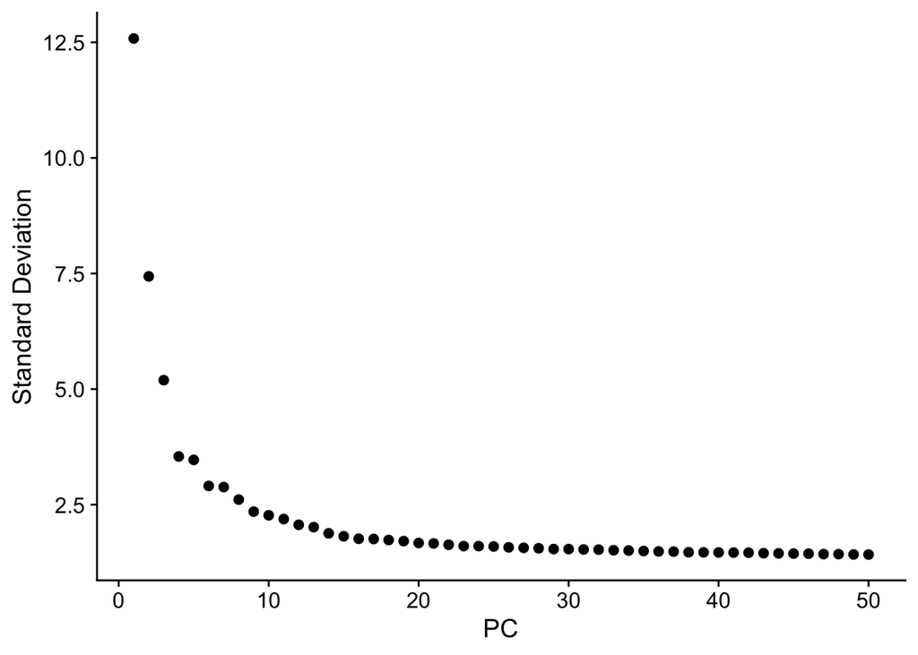

```r
slv14 = RunPCA(slv14, assay = "SCT", npcs = 50)

ElbowPlot(slv14, ndims = 50)
```

```r
slv14 <- FindNeighbors(slv14, reduction = "pca", dims = 1:15)
slv14 <- FindClusters(slv14, resolution = 0.4)
```

```
Modularity Optimizer version 1.3.0 by Ludo Waltman and Nees Jan van Eck

Number of nodes: 28038
Number of edges: 920217

Running Louvain algorithm...
Maximum modularity in 10 random starts: 0.8987
Number of communities: 10
Elapsed time: 7 seconds
```

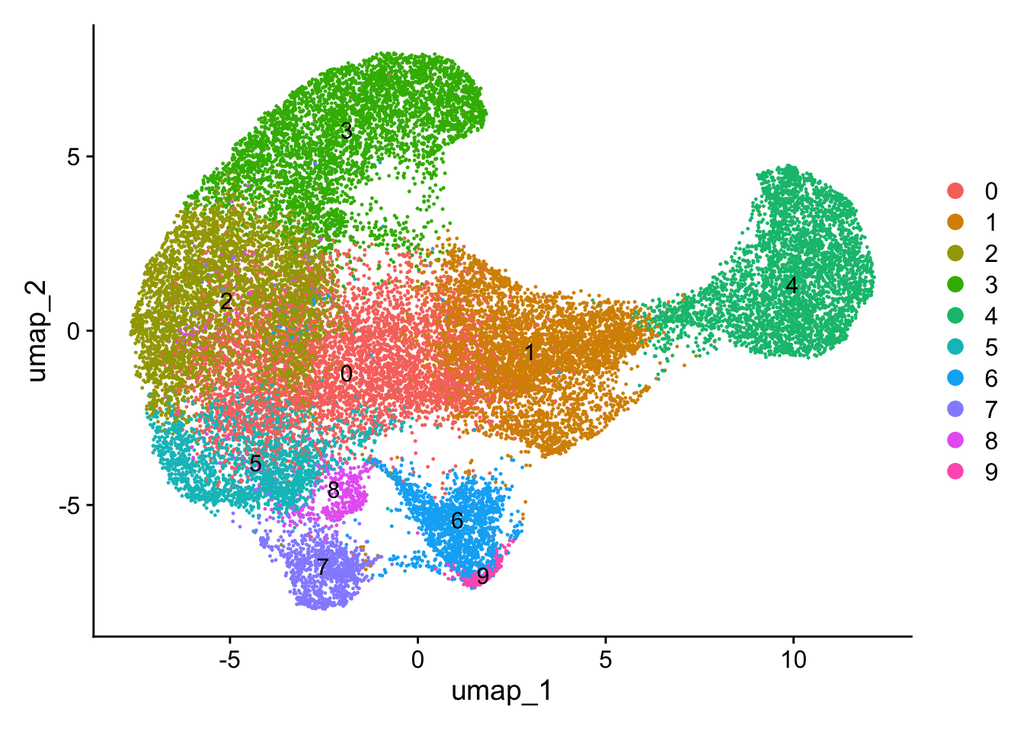

```r
slv14 <- RunUMAP(slv14, dims = 1:15)

DimPlot(slv14, reduction = "umap", label = TRUE)
```

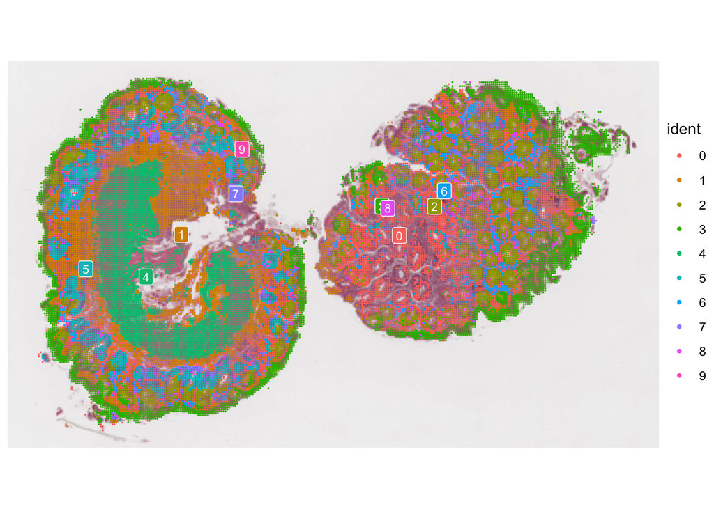

```r
SpatialDimPlot(slv14, label = TRUE, label.size = 3)
```

#### Data Markers

#TODO: Revisit empty cluster 0.

```r
slv14_markers <- FindAllMarkers(slv14, only.pos = TRUE, min.pct = 0.10, logfc.threshold = 0.25)

slv14_top_markers <- slv14_markers %>% filter(p_val_adj < 0.05, pct.1 - pct.2 > 0.10) %>% group_by (cluster) %>% slice_max(avg_log2FC, n = 10)

print(slv14_top_markers)
```

```
# A tibble: 80 × 7
# Groups:   cluster [9]
       p_val avg_log2FC pct.1 pct.2 p_val_adj cluster gene
       <dbl>      <dbl> <dbl> <dbl>     <dbl> <fct>   <chr>
 1 0               4.28 0.151 0.011 0         1       EGFL7
 2 0               3.99 0.121 0.011 0         1       VWF
 3 0               3.29 0.19  0.023 0         1       C3
 4 0               2.73 0.192 0.031 0         1       TNXB
 5 3.88e-256       2.51 0.139 0.026 7.02e-252 1       GPX3
 6 0               2.44 0.258 0.057 0         1       CD163
 7 1.35e-294       2.43 0.192 0.044 2.45e-290 1       APOE
 8 6.47e-313       2.40 0.197 0.044 1.17e-308 1       STAB1
 9 3.90e-217       2.39 0.131 0.027 7.05e-213 1       FBN1
10 6.59e-251       2.21 0.164 0.037 1.19e-246 1       DCN
# ℹ 70 more rows
```

#### Data Module Scoring

Module scoring was used to determine transcription activity for each bin population profile quantitatively.

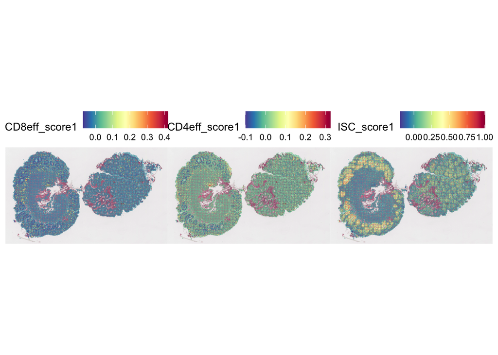

```r
cd8_eff_genes <- c("CD3E","CD3G","CD3D","NKG7","CST7","GZMK","GZMH","CD8A","GZMB","GZMM","GZMA","PRF1","LYST","LAG3","APOBEC3G")
cd4_eff_genes <- c("CD3E","CD3G","CD3D","CD40LG","CD4","TNFRSF4","IL7R","CCR4","CD28","TNF","IL2","DYNLT3","DPP4","IL4I1","CCL20")
isc_genes     <- c("LGR5","ASCL2","SMOC2","MSI1","RARRES2","SOX9","CENPM","EPHB2","OLFM4")

slv14 <- AddModuleScore(slv14, features = list(cd8_eff_genes), name = "CD8eff_score")
slv14 <- AddModuleScore(slv14, features = list(cd4_eff_genes), name = "CD4eff_score")
slv14 <- AddModuleScore(slv14, features = list(isc_genes),     name = "ISC_score")

SpatialFeaturePlot(slv14, features = c("CD8eff_score1", "CD4eff_score1", "ISC_score1"))
```

#### Population Bin Correlation Testing

The module scores for each cell population of interest were compared with each other to identify if the presence of one enriched cell population indicates greater or lesser enrichment of the other in the same bin.

The results match with those suggested in the paper (CD4+ and CD8+ enrichment are positively correlated with each other; T cell and ISC enrichment are negatively correlated with each other)

```r
cor.test(slv14$ISC_score1, slv14$CD8eff_score1)
```

```
    Pearson's product-moment correlation

data:  slv14$ISC_score1 and slv14$CD8eff_score1
t = -21.706, df = 28036, p-value < 2.2e-16
alternative hypothesis: true correlation is not equal to 0
95 percent confidence interval:
 -0.1400540 -0.1170306
sample estimates:
       cor
-0.1285596
```

```r
cor.test(slv14$ISC_score1, slv14$CD4eff_score1)
```

```
    Pearson's product-moment correlation

data:  slv14$ISC_score1 and slv14$CD4eff_score1
t = -39.213, df = 28036, p-value < 2.2e-16
alternative hypothesis: true correlation is not equal to 0
95 percent confidence interval:
 -0.2390871 -0.2168937
sample estimates:
     cor
-0.22802
```

```r
cor.test(slv14$CD8eff_score1, slv14$CD4eff_score1)
```

```
    Pearson's product-moment correlation

data:  slv14$CD8eff_score1 and slv14$CD4eff_score1
t = 42.135, df = 28036, p-value < 2.2e-16
alternative hypothesis: true correlation is not equal to 0
95 percent confidence interval:
 0.2329965 0.2550128
sample estimates:
      cor
0.2440361
```